# Conservation prioritization

## Introduction

Phylogenetic diversity was originally conceived as a metric to inform conservation, and spatial conservation planning is a core application of spatial phylogenetics. Spatial conservation planning involves identifying priority locations for actions like the creation of new protected areas.

There are a diversity of sophisticated tools available for conservation planning. This package offers two complementary approaches. The first is its own greedy stepwise algorithm, implemented in `ps_prioritize()`, which ranks every site in the study area by conservation priority. The second is `ps_prioritizr()`, which sets up a conservation planning problem that can be solved with the [prioritizr](https://prioritizr.net) package, which uses integer linear programming to find optimal solutions and offers a wider range of planning features. Both approaches account for evolutionary relationships among all lineages (terminal taxa and larger clades), can use quantitative community data (rather than just binary presence-absence data), and can use quantitative data on the relative degree of protection offered by different types of protected area (rather than just binary protected-unprotected data).

The two approaches answer somewhat different questions:

- `ps_prioritize()` produces a **ranking** of sites. Rankings are nested, meaning the top 10 sites are always part of the top 20, which suits situations where protection will be added incrementally or opportunistically over time, or where no specific budget or target has been set. Its benefit function rewards protecting more of every lineage’s range without requiring a hard target, and its probabilistic mode reveals alternative sites of similar value. It requires no additional software. However, stepwise selection is not guaranteed to find the best possible set of sites for any particular budget, and it does not support spatial design considerations such as reserve compactness or connectivity.
- `ps_prioritizr()` produces an **optimal solution** to a specific planning problem, such as the cheapest set of sites that protects 30% of every lineage’s range, or the best set of sites within a fixed budget. Its targets map directly onto policy goals, and the resulting problem can be extended with any of prioritizr’s constraints and penalties, such as locking particular sites in or out, or favoring spatially compact reserve networks. However, it requires prioritizr and an optimization solver, solutions for different budgets are not nested, and some problems can be slow to solve to optimality.

The two can also be used together. For example, a `ps_prioritize()` ranking can guide the sequence of acquisitions, while `ps_prioritizr()` shows what an optimal network looks like for a given budget or target.

This vignette covers greedy stepwise prioritization (including performance curves, probabilistic prioritization, and conservation benefit functions), followed by optimization with prioritizr. Both use the package’s example data set for California mosses.

## Greedy stepwise prioritization via `ps_prioritize()`

`ps_prioritize()` performs conservation prioritization using a greedy stepwise algorithm that selects an ordered ranking of priority sites for the creation of new protected areas. A site’s priority ranking is a function of:

- its current protection level
- the occurrence quantities for all lineages present in the site, including terminal taxa and larger clades
- the evolutionary branch lengths of these lineages on the phylogeny, which represent their unique evolutionary heritage
- the impact that protecting the site would have on these lineages’ range-wide protection levels
- the compositional complementarity between the site, other high-priority sites, and existing protected areas
- the relative cost of protecting the site
- lambda, a free parameter determining the shape of the conservation benefit function (see below)

Let’s perform a conservation optimization that ranks every grid cell across the state.

At every step of the iterative `ps_prioritize()` algorithm, the marginal value of fully protecting each individual site is calculated. Under a basic optimization (`method = "optimal"`), the site with the highest marginal value is marked as protected, marginal values are re-calculated, and this process is repeated until all sites (or `max_iter` sites) are protected. Sites selected earlier in the process are considered higher priority.

In addition to the required spatial phylogenetic data set, there are two other optional data inputs that one might want to provide. The first is `init`, the location and effectiveness of existing protected areas. This can be binary data representing protected versus unprotected sites, or continuous data with values between 0 and 1 representing the degree of protection (for example, perhaps because a given spatial unit is only partially covered by protected land, or because land management in sites like national forests is only partly oriented toward biodiversity protection). During the conservation optimization, the protection level for newly protected sites is raised to 1 (or to an alternative level specified by the parameter `protection`), with greater benefit resulting from sites with lower initial values.

First let’s load the libraries we’ll need, and initialize a `phylospatial` data set using the example data for California mosses. (See `vignette("phylospatial-data")` for details on constructing `phylospatial` objects.) We’ll also create a variable called `init` specifying our (arbitrary) initial conservation values, and `cost` defining some hypothetical land cost data.

```r
library(phylospatial); library(tmap); library(magrittr)

ps <- moss()
set.seed(123)
init <- seq(1, 0, length.out = ps$n_sites)
cost <- runif(ps$n_sites, 10, 1000)
```

Now we’ll pass those inputs to `ps_prioritize()`. Plotting the result, the highest-priority sites are those with low rank values, shown in yellow.

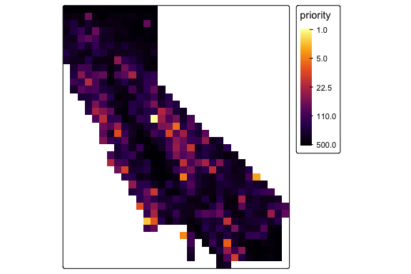

```r
priority <- ps_prioritize(ps, init = init, cost = cost)

tm_shape(priority) +
      tm_raster(col.scale = tm_scale_continuous_log(values = "-inferno")) +
      tm_layout(legend.outside = TRUE)
```

### Performance curves

To see how conservation value accumulates as sites are added in priority order, we can pass the prioritization result to `ps_performance()`, along with the data set used to create it. This returns a data frame with one row per step, tracking the cumulative number of sites, cost, and protection added (`gain`, which differs from the number of sites when some sites are already partially protected), along with the network’s conservation `value`. This is the quantity that `ps_prioritize()` optimizes: the branch-length-weighted sum of every lineage’s conservation benefit, which ranges from 0 to 1. Step 0 represents the starting state, which in our case is greater than zero because of the existing protection in `init`.

The curves also report target-based coverage: for each value supplied to `target`, the fraction of the tree’s total branch length belonging to lineages with at least that fraction of their range protected. Here we’ll look at 30% and 80% range protection targets. Our arbitrary `init` data already protect a large share of most lineages’ ranges, so nearly the whole tree meets the 30% target before any new sites are added; the 80% target is more informative in this example.

```
#>   ranking step site site_cost site_gain   site_value n_sites     cost      gain
#> 1       1    0   NA        NA        NA           NA       0  0.00000 0.0000000
#> 2       1    1  478  10.46070 0.4278027 0.0005387606       1 10.46070 0.4278027
#> 3       1    2  911  13.85738 0.8161435 0.0004835580       2 24.31808 1.2439462
#> 4       1    3  740  11.17971 0.6627803 0.0003816511       3 35.49779 1.9067265
#> 5       1    4  978  16.92847 0.8762332 0.0003753886       4 52.42626 2.7829596
#> 6       1    5  730  32.62614 0.6538117 0.0005694841       5 85.05239 3.4367713
#>       value     cov30     cov80
#> 1 0.9372342 0.9960357 0.1852520
#> 2 0.9377729 0.9960357 0.1898301
#> 3 0.9382565 0.9960403 0.1898301
#> 4 0.9386382 0.9960403 0.1898301
#> 5 0.9390135 0.9960584 0.1898301
#> 6 0.9395830 0.9960584 0.1898301
```

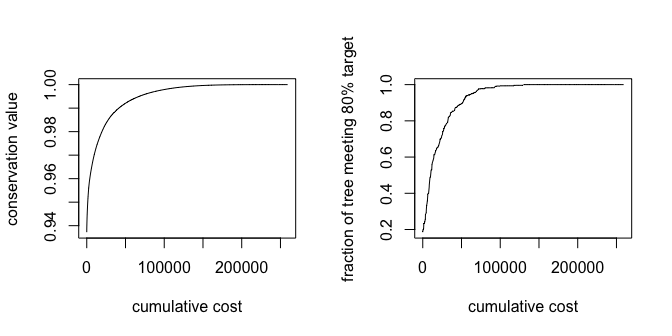

```r
perf <- ps_performance(ps, priority, target = c(.3, .8))
head(perf)

par(mfrow = c(1, 2))
plot(perf)
plot(perf, yvar = "cov80")
```

Curves like these show how quickly returns diminish, which can help in judging how much protection a given budget can buy. `ps_performance()` relies on metadata that `ps_prioritize()` attaches to its result, so it must be run on the object returned by `ps_prioritize()` rather than on a result that has been saved to file and reloaded. When used on a probabilistic prioritization, it summarizes curves across reps (or returns every rep’s curve, if `summarize = FALSE` was used).

### Probabilistic prioritization

The routine shown above gives the optimal priority ranking, based on the assumption that sites are selected in the optimal order. This is an informative result and a relatively lightweight computation, but it has limitations. First, assuming optimal behavior may be unrealistic. And second, since the algorithm values complementarity (i.e. protection of sites that have distinct, non-redundant biotic communities), sites with high conservation value that could be attractive real-world priorities can be entirely overlooked if they are compositionally similar to sites that were already selected because they have slightly higher value.

Probabilistic prioritization, activated with `method = "probable"`, addresses these issues. At each iteration, instead of protecting the site with the highest marginal value as done in the `"optimal"` method, this approach protects a random site, selected with a probability that is a function of the site’s marginal value. The trade-off is that individual runs of the algorithm can be highly variable, so the algorithm needs to be run many times, and prioritization rankings summarized across these repeated runs. When using the probabilistic method, `ps_prioritize()` returns summary statistics for each site including its average priority rank across reps, various quantiles of its rank distribution, and the proportion of reps in which a site was among the top-ranked sites.

Running a large number of `n_reps` can substantially increase computation times, but there are two ways to help mitigate run times. First, you can use parallel processing by increasing `n_cores` above the default of 1. Second, you can set `max_iter` to a relatively small number, which stops the algorithm after this number of sites have been added. For example, if your data set has 1000 sites, setting `max_iter = 10` can reduce run times by almost two orders of magnitude. While you won’t get a full rank prioritization of all sites from any individual rep, you will get the proportion of reps in which a site is in the top 10, which is arguably even more useful.

Let’s demonstrate that here; we’ll run 2500 reps, though more might be better for a real analysis:

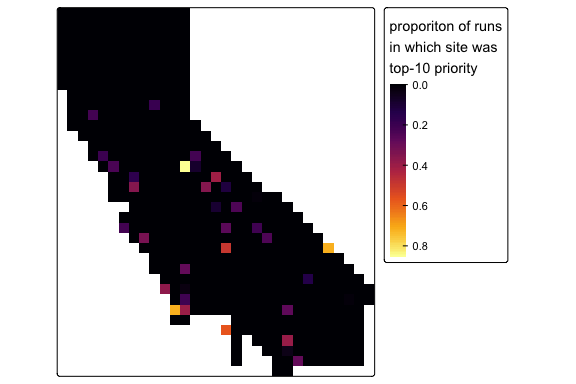

```r
priority <- ps_prioritize(ps, init = init, cost = cost, n_reps = 2500,
                          method = "prob", max_iter = 10)

tm_shape(priority$top10) +
      tm_raster(col.scale = tm_scale_continuous(values = "inferno"),
                col.legend = tm_legend(title = "proporiton of runs\nin which site was\ntop-10 priority")) +
      tm_layout(legend.outside = TRUE)
```

### Conservation benefit functions

In the examples above, we used the default value for the `lambda` parameter. `lambda` controls the relative priority placed on protecting initial populations of every taxon versus more populations of more phylogenetically distinct taxa. More precisely, it determines the shape of the `benefit()` function that converts the proportion of a taxon’s range that is protected into a conservation benefit measure that is used in calculating the marginal value of sites during prioritization.

We can use the function `plot_lambda()` to compare the shapes of benefit functions under different lambda values:

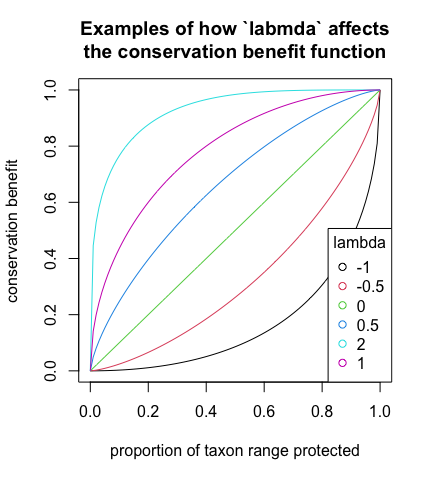

```r
plot_lambda()
```

A value of `lambda = 0` places equal marginal value on protecting additional populations of a taxon regardless of how much of its range is already protected. The default of `lambda = 1` places higher priority on protecting populations of unprotected taxa, but still places some value on increasing the protection of taxa that are already reasonably well protected. Increasing the value to `lambda = 2` strongly emphasizes protecting the first few percent of a taxon’s range, and places virtually no value on increasing protection beyond 50%. Lambda can also be negative, which places greater value on “finishing the job” of protecting the entire range of a lineage than on “starting the job” of protection a portion of its range; negative values are not likely to be useful in most practical applications.

Deciding which value to use is a subjective choice, and you should consider what makes the most sense for your particular use case. It can also be useful to compare different values to understand how sensitive your results may be to this choice.

## Optimization with `ps_prioritizr()`

The stepwise algorithm in `ps_prioritize()` produces a nested ranking of sites, but stepwise selection is not guaranteed to find the best possible set of sites for a given budget. The [prioritizr](https://prioritizr.net) package finds optimal solutions to conservation planning problems using integer linear programming, and offers a wide range of constraints and spatial penalties. The function `ps_prioritizr()` converts a `phylospatial` data set into a prioritizr problem, treating every branch of the phylogeny (terminal taxa and larger clades) as a conservation feature. This requires the prioritizr package and one of the optimization solvers it supports, such as highs.

All problems built by `ps_prioritizr()` are organized around a range protection `target`: the fraction of each lineage’s range that should be protected. The `objective` determines how targets are used:

- `"min_set"` finds the lowest-cost set of sites that brings every branch up to the target.
- `"targets"` maximizes the fraction of total branch length that meets the target, without exceeding a `budget`.
- `"shortfall"` maximizes progress toward the target, weighted by branch length and without exceeding a `budget`. Unlike `"targets"`, it gives credit for partial progress.

Existing protection specified via `init` counts toward each target, and selecting a site in a solution raises its protection level to `protection`, just as in `ps_prioritize()`. Sites that are already fully protected are locked into every solution at no cost.

prioritizr also has built-in phylogenetic objectives, `add_max_phylo_div_objective()` and `add_max_phylo_end_objective()`, which take a tree along with species-level features. These work differently from `ps_prioritizr()` in a few important ways:

- **How lineages get credit.** prioritizr’s phylogenetic objectives give special treatment to terminal taxa, which does not align with the clade-based view of biodiversity that is inherent in phylogenetic diversity metrics. They set targets for terminal taxa only, and credit a branch as conserved if at least one of its descendant taxa meets its target. Meeting the target for a single narrow-ranged species therefore credits all of its ancestral branches, even if only a small fraction of those clades’ ranges is protected. `ps_prioritizr()` instead treats every clade’s own range (the union of its descendants’ ranges, as computed by `phylospatial()`) as a feature with its own target, so deep branches only count once their own ranges are adequately protected. This is the same clade-level view of geographic ranges used throughout this package, and it extends naturally to probabilistic range data.
- **Partial credit and existing protection.** prioritizr’s phylogenetic objectives give all-or-nothing credit for each branch, while the `"shortfall"` objective here also rewards partial progress. Existing protection can only be represented in prioritizr by locking sites into the solution, whereas `ps_prioritizr()` counts partially protected sites (`init` values between 0 and 1) toward targets.
- **Endemism.** `add_max_phylo_end_objective()` weights each branch’s length by the inverse of its range size, favoring geographically restricted lineages. `ps_prioritizr()` weights branches by length alone, though because targets are defined as fractions of each lineage’s range, narrow-ranged lineages are generally cheaper to bring up to target.

Here we’ll find the lowest-cost set of sites that protects at least half of every lineage’s range, using the same `init` and `cost` data as above. `ps_prioritizr()` returns an unsolved problem, to which we can add any other prioritizr components before solving it. Here we’ll specify the solver, with an optimality gap of zero to ensure we get an exact solution (prioritizr solvers otherwise stop once they are within 10% of the optimum).

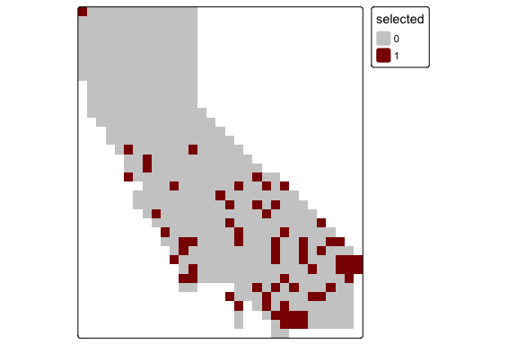

```r
library(prioritizr)

prob <- ps_prioritizr(ps, init = init, cost = cost,
                      objective = "min_set", target = .5) %>%
      add_default_solver(gap = 0, verbose = FALSE)

solution <- solve(prob)

tm_shape(solution) +
      tm_raster(col.scale = tm_scale_categorical(values = c("gray80", "darkred")),
                col.legend = tm_legend(title = "selected")) +
      tm_layout(legend.outside = TRUE)
```

The budget-constrained objectives work the same way, with a `budget` argument specifying the maximum total cost of newly selected sites. Note that `"targets"` problems can take much longer to solve to optimality than the other objectives; a small nonzero `gap` or a `time_limit` can help.

Spatial penalties and constraints can be added in the same way; for example, `add_boundary_penalties()` favors spatially compact solutions. By default, `ps_prioritizr()` builds the problem using the spatial data in our `phylospatial` object, so prioritizr can calculate the spatial relationships among sites itself. For very large data sets, `spatial = FALSE` builds a more memory-efficient non-spatial problem instead.

Note that prioritizr’s own summary functions, like `eval_feature_representation_summary()`, report each branch’s representation relative to the unprotected portion of its range rather than its full range, since `ps_prioritizr()` builds existing protection into its targets.